# Praca domowa 2 - raport

Jan Cichowlas

28 marca 2022

# Opis

Celem niniejszej pracy jest ukazanie najczęstrzych błedów popełnianych przy tworzeniu wykresów dostępnych w mediach. Przyjrzymy się jednemu z tych przypadków oraz zaproponujemy poprawioną wersję wykresu.

# Przykład złego wykresu

### Źródło

Przykład, który omówimy pochodzi z artykułu: https://300gospodarka.pl/explainer/zakaz-importu-ropy-z-rosji-jakie-skutki-dla-polski.

### Wykres

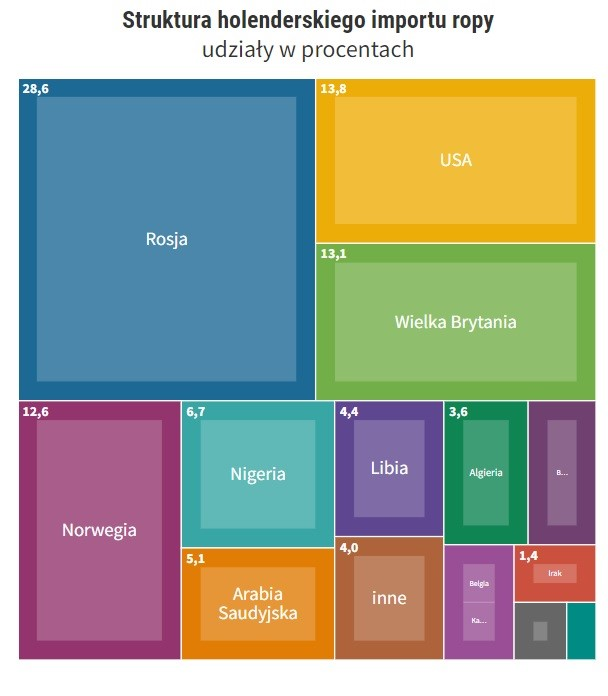

### Błędy

Jakie błędy możemy zauważyć na powyższym wykresie? Myślę, że główną jego wadą jest fakt, iż ludzkie oko nie radzi sobie aż tak dobrze z porównywaniem pól prostokątów odpowiadających poszczególnym kategoriom, aby wyciągać z nich poprawne i dokładne wnioski. Powinniśmy być w stanie porównać ze sobą dwa dowolne kraje, co jest niemożliwe na przykład w przypadku USA i Wielkiej Brytanii. Gdyby nie podpisy z udziałem procentowym każdej kategorii, nie moglimyśmy roztrzygnąć, od kogo Holandia kupuje więcej ropy. Po drugie, zastosowane kolory, nie wnoszą żadnych dodatkowych informacji.

# Poprawa wykresu

Jak możemy przedstawić te dane w sposób bardziej czytelny?

### Odczytanie surowych danych

Posługując się wykresem, możemy odzyskać dane w nim zawarte. Kraje o bardzo małym eksporcie ropy do Holandii, których nazw nie daje się odczytać, również zaklasyfikujemy jako “inne”. Otrzymujemy ramkę danych:

```
##            panstwo udzial
## 1            Rosja   28.6
## 2              USA   13.8
## 3  Wielka Brytania   13.1
## 4         Norwegia   12.6
## 5          Nigeria    6.7
## 6 Arabia Saudyjska    5.1
## 7            Libia    4.4
## 8         Algieria    3.6
## 9             inne   12.1
```

### Nowy wykres

Za pomocą poniższego kodu, korzystając z pakietu ggplot2, możemy stworzyć następujący wykres:

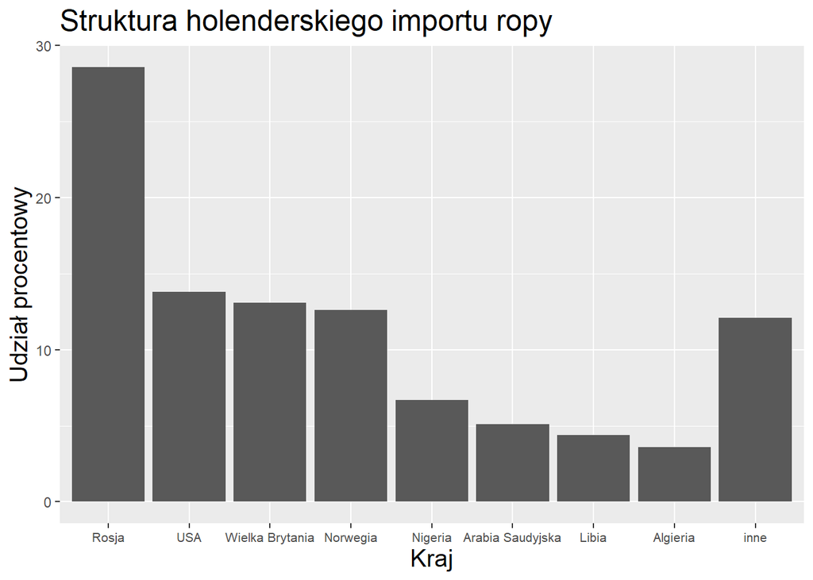

```r
ggplot(data = Dane, aes(x = reorder(panstwo, 1:9),
                        y = udzial)) +
  geom_col() +
  labs(title = "Struktura holenderskiego importu ropy",
       x = "Kraj",
       y = "Udział procentowy") +
  theme(axis.text.x = element_text(size = 8),
        axis.title.x = element_text(size = 15),
        axis.title.y = element_text(size = 15),
        title = element_text(size = 15))
```

# Podsumowanie

Nowy wykres jest o wiele bardziej czytelny od tego starego. Pozwala na dokładniejsze porównanie poszczególnych krajów i nie rozprasza nas nieuzasadnionym użyciem koloru.